# p131 final project

Xuejun Zhao

2022-12-03

## Introduction

The World Population Data Set contains Height, Weight, IQ, Quality of Life etc. This paper intends to analyze which factors affect the life span of the population through characteristics. Based on these characteristics, the life prediction is made by machine learning.The basic information of the feature is as follows.Most of the features are numeric. Country is a character feature.

```r
getwd()
```

```
## [1] "/Users/xuejunzhao/Desktop/Pstat 131"
```

```r
Population <- read.csv("df.csv",header=TRUE,sep = ",")
Population <- Population[,c(2:25)]
Population['life_expectancy']<-(Population['male_life_expectancy']+Population['female_life_expectancy'])/2
str(Population)
```

```
## 'data.frame':    115 obs. of  25 variables:
##  $ country                             : chr  "Hong Kong" "Iceland" "Japan" "Norway" ...
##  $ male_life_expectancy                : num  82.9 81.7 81.6 81.6 81.5 81.4 81.2 81.1 80.8 80.7 ...
##  $ female_life_expectancy              : num  88 84.5 87.7 84.9 86.1 87.3 85.3 85.2 84.6 84.8 ...
##  $ birth_rate                          : num  5.8 12.3 6.8 9.8 8.5 10.7 11.5 9.9 8.6 19.2 ...
##  $ death_rate                          : num  6.8 7.8 8.8 9.8 10.8 4.1 6.3 8.8 7.9 5.3 ...
##  $ stability                           : num  77 82 87 89 83 90 86 91 86 57 ...
##  $ rights                              : num  85 92 86 99 89 71 92 99 72 72 ...
##  $ health                              : num  100 87 92 90 79 100 87 93 91 84 ...
##  $ safety                              : num  97 97 97 99 100 93 100 99 92 81 ...
##  $ climate                             : num  49 7 54 17 45 48 90 34 75 81 ...
##  $ costs                               : num  61 36 27 42 55 61 23 44 41 36 ...
##  $ popularity                          : num  52 33 41 37 42 50 41 40 44 30 ...
##  $ iq                                  : num  108 101 105 99 108 101 99 102 97 94 ...
##  $ education_expenditure_per_inhabitant: chr  "915" "2,443" "1,258" "3,527" ...
##  $ daily_max_temp                      : num  26.2 8.1 19.2 9 31.5 26 24.4 15.1 23.1 25.4 ...
##  $ area                                : num  NA NA 377970 385203 719 ...
##  $ population                          : chr  "" "" "125.68 M" "5.41 M" ...
##  $ pop_per_km_sq                       : num  NA NA 332 14 7585 ...
##  $ male_height                         : num  174 181 172 180 173 NA 179 179 174 176 ...
##  $ female_height                       : num  160 168 158 166 161 NA 165 164 162 162 ...
##  $ male_weight                         : num  74.4 89.2 69.5 89.1 72.8 NA 88.3 85.5 84.2 85.4 ...
##  $ female_weight                       : num  61.1 72.6 54.8 72.6 60.2 NA 72.6 63.9 70.5 71.1 ...
##  $ male_bmi                            : num  24.5 27.1 23.6 27.4 24.3 NA 27.7 26.8 27.9 27.7 ...
##  $ female_bmi                          : num  23.8 25.6 21.9 26.2 23.2 NA 26.8 23.8 26.7 27.1 ...
##  $ life_expectancy                     : num  85.5 83.1 84.7 83.2 83.8 ...
```

## Missing value processing

The deleted features:“area”,“pop_per_km_sq”,“male_life_expectancy”,“female_life_expectancy”,“population”.At the same time, we turn character data into factor.

```r
options(digits = 2)
Population <- mutate_if(Population, is.character, as.factor)
Population <- mutate_if(Population, is.numeric, as.integer)
knitr::kable(Population %>%
  miss_var_summary(), format="html")
```

| variable | n_miss | pct_miss |
| --- | --- | --- |
| area | 55 | 47.8 |
| pop_per_km_sq | 55 | 47.8 |
| male_height | 17 | 14.8 |
| female_height | 17 | 14.8 |
| male_weight | 17 | 14.8 |
| female_weight | 17 | 14.8 |
| male_bmi | 17 | 14.8 |
| female_bmi | 17 | 14.8 |
| iq | 13 | 11.3 |
| daily_max_temp | 13 | 11.3 |
| stability | 11 | 9.6 |
| rights | 11 | 9.6 |
| health | 11 | 9.6 |
| safety | 11 | 9.6 |
| climate | 11 | 9.6 |
| costs | 11 | 9.6 |
| popularity | 11 | 9.6 |
| country | 0 | 0.0 |
| male_life_expectancy | 0 | 0.0 |
| female_life_expectancy | 0 | 0.0 |
| birth_rate | 0 | 0.0 |
| death_rate | 0 | 0.0 |
| education_expenditure_per_inhabitant | 0 | 0.0 |
| population | 0 | 0.0 |
| life_expectancy | 0 | 0.0 |

```r
Population1 <- Population %>% select(-c("area","pop_per_km_sq","male_life_expectancy","female_life_expectancy","population"))
Population1$education_expenditure_per_inhabitant<-as.numeric(gsub(",","",Population1$education_expenditure_per_inhabitant))
Population2 <- Population1 %>%
  map_dfc(~ replace_na(.x, rstatix::get_mode(.x)[1]))
knitr::kable(Population2 %>%
  miss_var_summary(), format="html")
```

| variable | n_miss | pct_miss |
| --- | --- | --- |
| country | 0 | 0 |
| birth_rate | 0 | 0 |
| death_rate | 0 | 0 |
| stability | 0 | 0 |
| rights | 0 | 0 |
| health | 0 | 0 |
| safety | 0 | 0 |
| climate | 0 | 0 |
| costs | 0 | 0 |
| popularity | 0 | 0 |
| iq | 0 | 0 |
| education_expenditure_per_inhabitant | 0 | 0 |
| daily_max_temp | 0 | 0 |
| male_height | 0 | 0 |
| female_height | 0 | 0 |
| male_weight | 0 | 0 |
| female_weight | 0 | 0 |
| male_bmi | 0 | 0 |
| female_bmi | 0 | 0 |
| life_expectancy | 0 | 0 |

## Exploratory data analysis

For the convenience of analysis, we divide the data into numerical data and character data. The skim function from the skimr package produces the summary output below, showing that we have 115 observations and 20 variables. There are 1 character variables and 19 numeric.

```r
Population_count <- data.frame(Population2[, sapply(Population2, is.numeric)])
Population_factor <- Population2[, sapply(Population2, is.factor)]
skim(Population2)
```

Data summary

| Name | Population2 |
| --- | --- |
| Number of rows | 115 |
| Number of columns | 20 |
| _______________________ |  |
| Column type frequency: |  |
| factor | 1 |
| numeric | 19 |
| ________________________ |  |
| Group variables | None |

**Variable type: factor**

| skim_variable | n_missing | complete_rate | ordered | n_unique | top_counts |
| --- | --- | --- | --- | --- | --- |
| country | 0 | 1 | FALSE | 115 | Afg: 1, Alb: 1, Alg: 1, Ang: 1 |

**Variable type: numeric**

| skim_variable | n_missing | complete_rate | mean | sd | p0 | p25 | p50 | p75 | p100 | hist |
| --- | --- | --- | --- | --- | --- | --- | --- | --- | --- | --- |
| birth_rate | 0 | 1 | 16.4 | 9.2 | 5 | 9 | 13 | 21.0 | 41 | ▇▅▂▂▂ |
| death_rate | 0 | 1 | 7.7 | 3.3 | 1 | 6 | 7 | 9.5 | 18 | ▂▇▆▂▁ |
| stability | 0 | 1 | 58.4 | 19.4 | 8 | 46 | 58 | 74.5 | 93 | ▁▃▇▆▆ |
| rights | 0 | 1 | 51.2 | 26.4 | 7 | 26 | 45 | 73.0 | 100 | ▇▇▆▅▆ |
| health | 0 | 1 | 64.2 | 25.2 | 0 | 50 | 69 | 87.0 | 100 | ▂▂▃▇▇ |
| safety | 0 | 1 | 80.3 | 21.3 | 10 | 76 | 89 | 93.0 | 100 | ▁▁▁▂▇ |
| climate | 0 | 1 | 51.1 | 19.2 | 2 | 42 | 52 | 62.5 | 95 | ▂▂▇▃▂ |
| costs | 0 | 1 | 51.0 | 11.8 | 23 | 44 | 49 | 60.0 | 76 | ▂▆▇▇▃ |
| popularity | 0 | 1 | 37.1 | 10.7 | 11 | 33 | 36 | 42.0 | 73 | ▂▇▇▁▁ |
| iq | 0 | 1 | 87.1 | 11.4 | 56 | 83 | 86 | 97.0 | 108 | ▂▂▇▅▅ |
| education_expenditure_per_inhabitant | 0 | 1 | 517.4 | 762.6 | 3 | 19 | 122 | 712.5 | 3527 | ▇▁▁▁▁ |
| daily_max_temp | 0 | 1 | 24.2 | 8.1 | 7 | 18 | 26 | 32.0 | 36 | ▂▅▃▅▇ |
| male_height | 0 | 1 | 173.3 | 5.0 | 159 | 170 | 173 | 177.0 | 184 | ▁▃▇▅▂ |
| female_height | 0 | 1 | 160.7 | 4.2 | 152 | 158 | 160 | 164.0 | 170 | ▃▃▇▅▂ |
| male_weight | 0 | 1 | 76.3 | 9.7 | 53 | 71 | 74 | 85.0 | 91 | ▂▃▇▃▇ |
| female_weight | 0 | 1 | 67.1 | 7.1 | 49 | 63 | 70 | 72.0 | 80 | ▂▂▃▇▂ |
| male_bmi | 0 | 1 | 25.4 | 2.2 | 20 | 24 | 26 | 27.0 | 29 | ▁▂▂▇▁ |
| female_bmi | 0 | 1 | 25.4 | 2.0 | 21 | 24 | 26 | 26.0 | 31 | ▃▃▇▂▁ |
| life_expectancy | 0 | 1 | 74.0 | 7.3 | 53 | 70 | 76 | 80.0 | 85 | ▁▂▅▇▆ |

## Exploring Target Variable

We use hist plot to analyze the distribution of the target variable.From the figure,the distribution of the target variable is skewed.

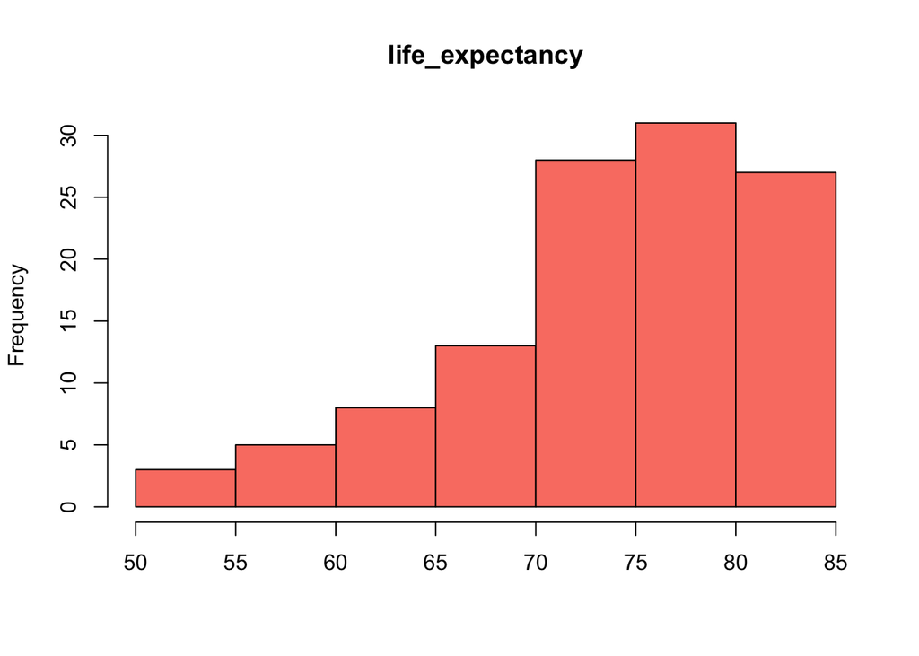

```r
hist(Population_count[, c('life_expectancy')], main = 'life_expectancy', xlab = "",col = 'salmon')
```

## Exploring Numerical Variables

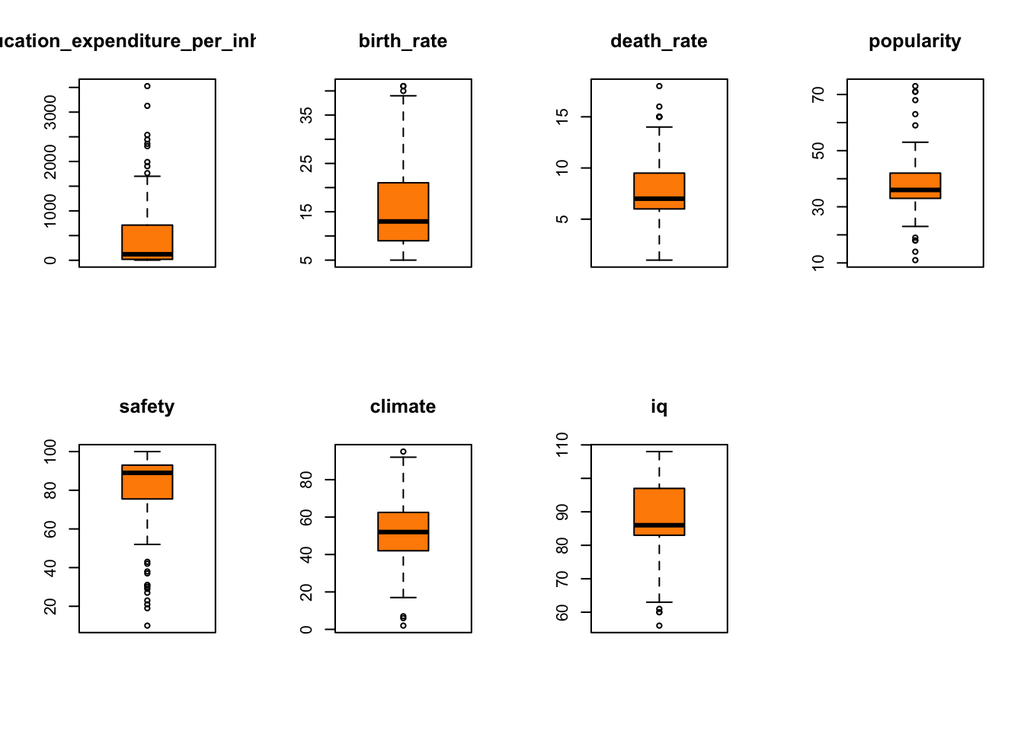

```r
cols = c('education_expenditure_per_inhabitant','birth_rate','death_rate','popularity','safety','climate','iq')
par(mfrow = c(2, 4))
names <- names(Population_count[,cols])
for (i in names) {
  boxplot(Population_count[, i], main = i,col = 'darkorange')
}
for (i in cols){
  Q3 <- quantile(Population_count[,i], 0.95)
  Q1 <- quantile(Population_count[,i], 0.05)
  IQR <- Q3 - Q1
  s1 <- Q1 - 1.5 * IQR
  s2 <- Q3 + 1.5 * IQR
  value = mean(Population_count[,i])
  Population_count[,i] <- ifelse(Population_count[,i]<s1|Population_count[,i]>s2,value,Population_count[,i])
}
```

Next, let’s look at the correlation of variables as shown in the following figure We find that some variables are highly correlated, so it is necessary to reduce the dimension before predicting.

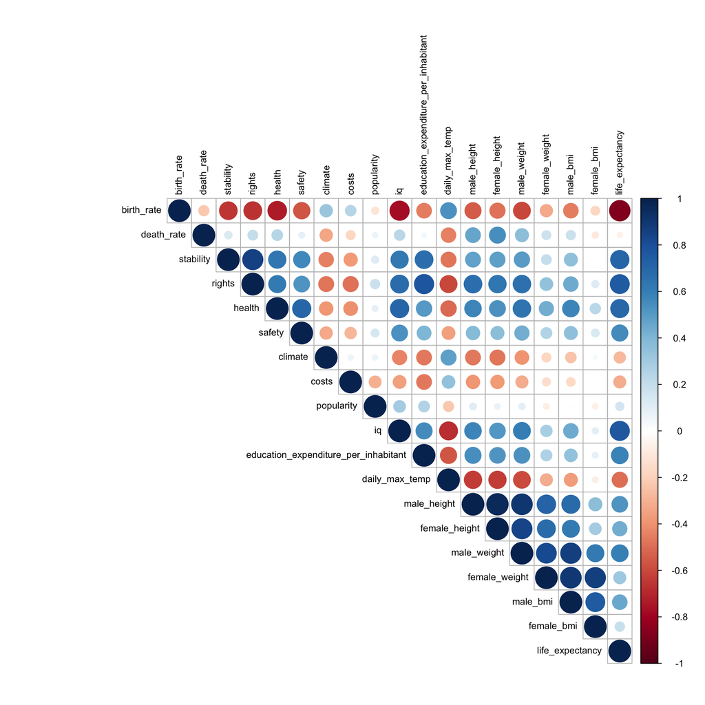

```r
correlations <- cor(Population_count,method="pearson")
corrplot(correlations, number.cex = .9, method = "circle", type = "upper", tl.cex=0.8,tl.col = "black")
```

## PCA

The dimensionality reduction by principal component analysis shows that the interpretability of variance is 91% when 8 principal components are retained.

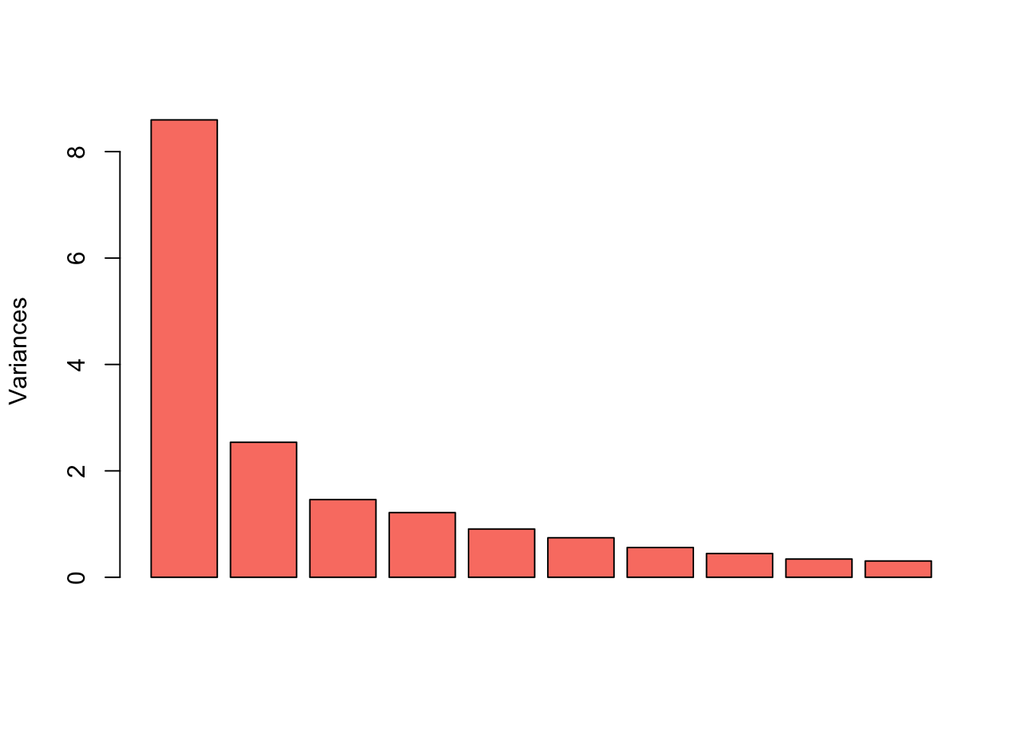

```r
pca <- prcomp(Population_count[,-c(19)], scale = TRUE)
screeplot(pca,col = 'salmon',main = '')
```

```r
gof <- (pca$sdev)^2/sum((pca$sdev)^2)
sum(gof[1:8])
```

```
## [1] 0.91
```

```r
Population_pca <- pca$x[,c(1:8)]
```

## Data Processing

Next, we convert country to numeric data through the function step_dummy.

```r
X<-data.frame(Population_pca,Population_factor,Population_count['life_expectancy'])
X<-as_tibble(X)
model_recipe <-
  recipe(life_expectancy ~ ., data = X) %>%
  step_dummy(country, one_hot = TRUE)
```

## Data Spliting-Cross Validation

```r
set.seed(123)
X_split <- initial_split(X, prop = 0.8, strata = "life_expectancy")
X_train <- training(X_split)
X_test  <- testing(X_split)
set.seed(456)
l_cv <- vfold_cv(X_train, v = 5,strata = "life_expectancy") # Cross validation
```

## Modeling

We used four models. They are glmnet (lasso), knn, descent tree and random forest.All models seemed to perform comparatively well and we did everything using tidymodels.recipes packages was used for data pre-processing.parnsip was used for estimation (more precisely as a wrapper around the individual modeling packages).rsample was used to split the data for cross validation.tune and dials were used for parameter tuning.workflows was used to put it all together.This worked great from a usability perspective. Trying different models and tuning their parameters was all done using the same interface.

### model-1 lasso regression

```r
# Lasso Regression
lin_model <-
  linear_reg(mode = "regression",
             penalty = tune(),
             mixture = 1,
             engine = "glmnet"
  )
lin_wf <-
  workflow() %>%
  add_model(lin_model) %>%
  add_recipe(model_recipe)
# Hyperparameter Tuning
lin_results <-
  lin_wf %>%
  tune_grid(resamples = l_cv,
            metrics = metric_set(rsq, rmse, mae)
  )
lin_wf
```

```
## ══ Workflow ════════════════════════════════════════════════════════════════════
## Preprocessor: Recipe
## Model: linear_reg()
##
## ── Preprocessor ────────────────────────────────────────────────────────────────
## 1 Recipe Step
##
## • step_dummy()
##
## ── Model ───────────────────────────────────────────────────────────────────────
## Linear Regression Model Specification (regression)
##
## Main Arguments:
##   penalty = tune()
##   mixture = 1
##
## Computational engine: glmnet
```

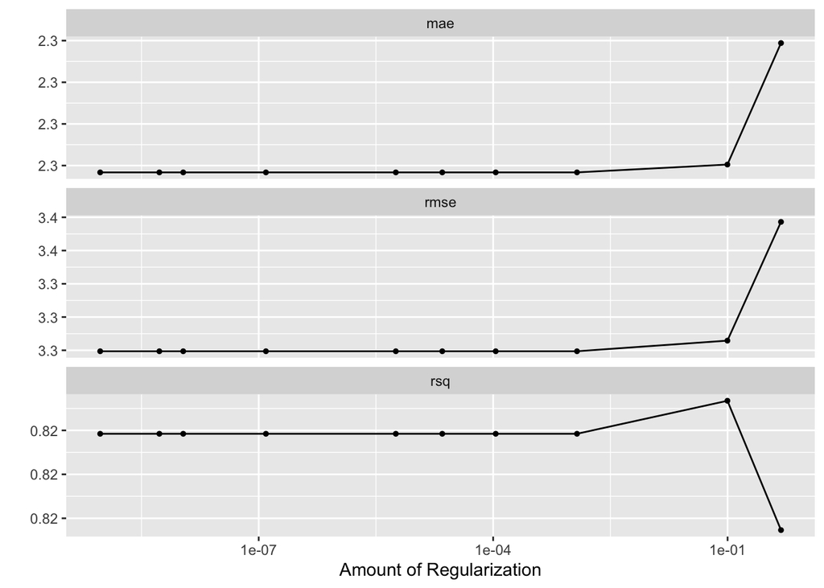

```r
autoplot(lin_results)
```

```r
collect_metrics(lin_results)
```

| penalty | .metric | .estimator | mean | n | std_err | .config |
| --- | --- | --- | --- | --- | --- | --- |
| 9.4e-10 | mae | standard | 2.32 | 5 | 0.156 | Preprocessor1_Model01 |
| 9.4e-10 | rmse | standard | 3.30 | 5 | 0.424 | Preprocessor1_Model01 |
| 9.4e-10 | rsq | standard | 0.82 | 5 | 0.024 | Preprocessor1_Model01 |
| 5.4e-09 | mae | standard | 2.32 | 5 | 0.156 | Preprocessor1_Model02 |
| 5.4e-09 | rmse | standard | 3.30 | 5 | 0.424 | Preprocessor1_Model02 |
| 5.4e-09 | rsq | standard | 0.82 | 5 | 0.024 | Preprocessor1_Model02 |
| 1.1e-08 | mae | standard | 2.32 | 5 | 0.156 | Preprocessor1_Model03 |
| 1.1e-08 | rmse | standard | 3.30 | 5 | 0.424 | Preprocessor1_Model03 |
| 1.1e-08 | rsq | standard | 0.82 | 5 | 0.024 | Preprocessor1_Model03 |
| 1.2e-07 | mae | standard | 2.32 | 5 | 0.156 | Preprocessor1_Model04 |

[output cut: 20 more lines]

```r
# Final Hyperparameter
param_final <- lin_results %>%
  select_best(metric = "mae")
lin_wf <- lin_wf %>%
  finalize_workflow(param_final)
# last fit
lin_fit <- lin_wf %>%
     last_fit(X_split)
# Test Data Predictions
test_performance <- lin_fit %>% collect_predictions()
# Performance metrics
auto_metrics <- metric_set(rsq, rmse, mae)
x1 <- auto_metrics(data = test_performance, truth = life_expectancy, estimate = .pred)
x1['model'] <- 'lasso'
x1
```

| .metric | .estimator | .estimate | model |
| --- | --- | --- | --- |
| rsq | standard | 0.86 | lasso |
| rmse | standard | 3.17 | lasso |
| mae | standard | 2.49 | lasso |

### model-2 KNN

```r
# K - Nearest Neighbor
knn_model <-
  nearest_neighbor( mode = "regression",
                    neighbors = tune(),
                    weight_func = tune(),
                    dist_power = tune(),
                    engine = "kknn"
  )
knn_wf <-
  workflow() %>%
  add_model(knn_model) %>%
  add_recipe(model_recipe)
knn_wf
```

```
## ══ Workflow ════════════════════════════════════════════════════════════════════
## Preprocessor: Recipe
## Model: nearest_neighbor()
##
## ── Preprocessor ────────────────────────────────────────────────────────────────
## 1 Recipe Step
##
## • step_dummy()
##
## ── Model ───────────────────────────────────────────────────────────────────────
## K-Nearest Neighbor Model Specification (regression)
##
## Main Arguments:
##   neighbors = tune()
##   weight_func = tune()
##   dist_power = tune()
##
## Computational engine: kknn
```

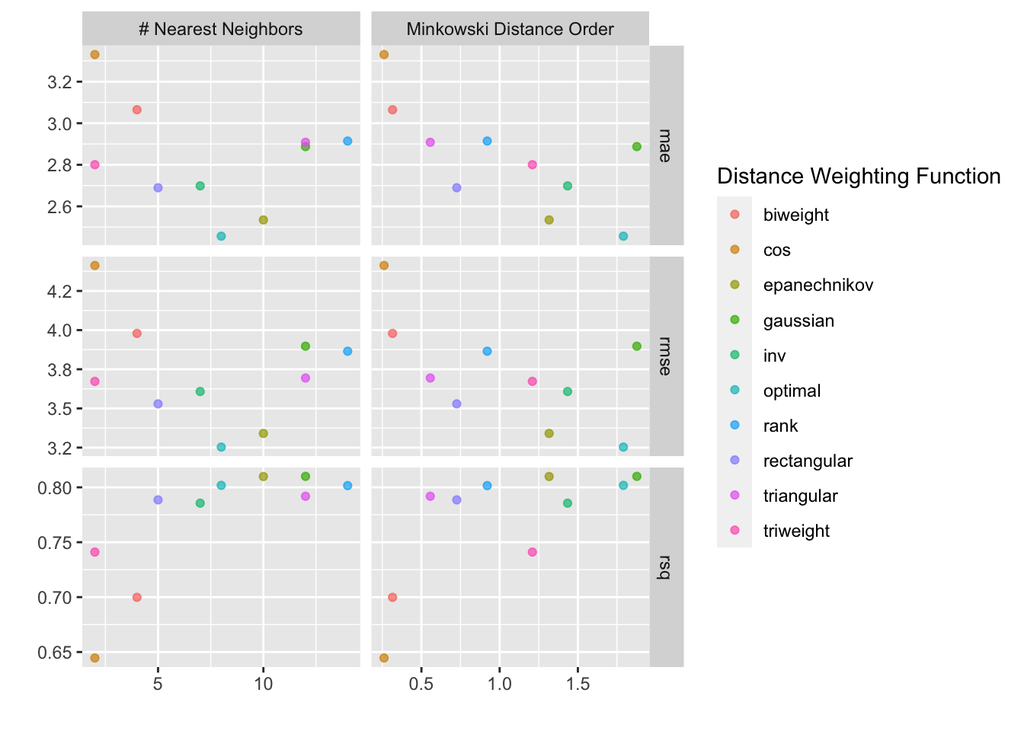

```r
# Hyperparameter Tuning
knn_results <-
  knn_wf %>%
  tune_grid(resamples = l_cv,
            metrics = metric_set(rsq, rmse, mae)
  )
autoplot(knn_results)
```

```r
collect_metrics(knn_results)
```

| neighbors | weight_func | dist_power | .metric | .estimator | mean | n | std_err | .config |
| --- | --- | --- | --- | --- | --- | --- | --- | --- |
| 4 | biweight | 0.32 | mae | standard | 3.06 | 5 | 0.258 | Preprocessor1_Model01 |
| 4 | biweight | 0.32 | rmse | standard | 3.98 | 5 | 0.349 | Preprocessor1_Model01 |
| 4 | biweight | 0.32 | rsq | standard | 0.70 | 5 | 0.056 | Preprocessor1_Model01 |
| 2 | cos | 0.26 | mae | standard | 3.33 | 5 | 0.388 | Preprocessor1_Model02 |
| 2 | cos | 0.26 | rmse | standard | 4.41 | 5 | 0.544 | Preprocessor1_Model02 |
| 2 | cos | 0.26 | rsq | standard | 0.64 | 5 | 0.077 | Preprocessor1_Model02 |
| 10 | epanechnikov | 1.32 | mae | standard | 2.53 | 5 | 0.077 | Preprocessor1_Model03 |
| 10 | epanechnikov | 1.32 | rmse | standard | 3.34 | 5 | 0.196 | Preprocessor1_Model03 |
| 10 | epanechnikov | 1.32 | rsq | standard | 0.81 | 5 | 0.023 | Preprocessor1_Model03 |
| 12 | gaussian | 1.88 | mae | standard | 2.89 | 5 | 0.292 | Preprocessor1_Model04 |

[output cut: 20 more lines]

```r
# Final Hyperparameter
param_final <- knn_results %>%
  select_best(metric = "mae")
knn_wf <- knn_wf %>%
  finalize_workflow(param_final)
# last fit
knn_fit <- knn_wf %>%
  last_fit(X_split)
# Test Data Predictions
test_performance <- knn_fit %>% collect_predictions()
# Performance metrics
auto_metrics <- metric_set(rsq, rmse, mae)
x2 <- auto_metrics(data = test_performance, truth =  life_expectancy, estimate = .pred)
x2['model'] <- 'knn'
x2
```

| .metric | .estimator | .estimate | model |
| --- | --- | --- | --- |
| rsq | standard | 0.87 | knn |
| rmse | standard | 2.93 | knn |
| mae | standard | 2.36 | knn |

### model-3 descision tree

```r
# Decision Trees
dt_model <-
  decision_tree(mode = "regression",
                cost_complexity = tune(),
                tree_depth = tune(),
                min_n = tune(),
                engine = "rpart"
  )
dt_wf <-
  workflow() %>%
  add_model(dt_model) %>%
  add_recipe(model_recipe)
dt_wf
```

```
## ══ Workflow ════════════════════════════════════════════════════════════════════
## Preprocessor: Recipe
## Model: decision_tree()
##
## ── Preprocessor ────────────────────────────────────────────────────────────────
## 1 Recipe Step
##
## • step_dummy()
##
## ── Model ───────────────────────────────────────────────────────────────────────
## Decision Tree Model Specification (regression)
##
## Main Arguments:
##   cost_complexity = tune()
##   tree_depth = tune()
##   min_n = tune()
##
## Computational engine: rpart
```

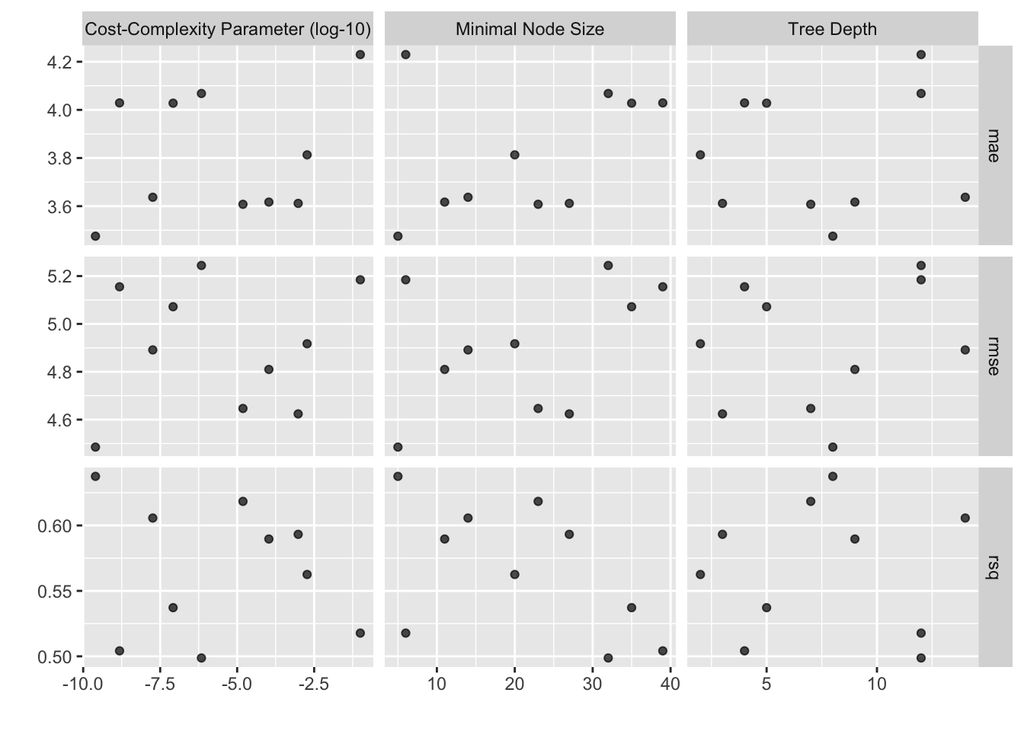

```r
# Hyperparameter Tuning
dt_results <-
  dt_wf %>%
  tune_grid(resamples = l_cv,
            metrics = metric_set(rsq, rmse, mae)
  )
autoplot(dt_results)
```

```r
collect_metrics(dt_results)
```

| cost_complexity | tree_depth | min_n | .metric | .estimator | mean | n | std_err | .config |
| --- | --- | --- | --- | --- | --- | --- | --- | --- |
| 1.0e-01 | 12 | 6 | mae | standard | 4.23 | 5 | 0.256 | Preprocessor1_Model01 |
| 1.0e-01 | 12 | 6 | rmse | standard | 5.18 | 5 | 0.317 | Preprocessor1_Model01 |
| 1.0e-01 | 12 | 6 | rsq | standard | 0.52 | 5 | 0.061 | Preprocessor1_Model01 |
| 9.6e-04 | 3 | 27 | mae | standard | 3.61 | 5 | 0.351 | Preprocessor1_Model02 |
| 9.6e-04 | 3 | 27 | rmse | standard | 4.62 | 5 | 0.362 | Preprocessor1_Model02 |
| 9.6e-04 | 3 | 27 | rsq | standard | 0.59 | 5 | 0.077 | Preprocessor1_Model02 |
| 1.5e-09 | 4 | 39 | mae | standard | 4.03 | 5 | 0.109 | Preprocessor1_Model03 |
| 1.5e-09 | 4 | 39 | rmse | standard | 5.16 | 5 | 0.185 | Preprocessor1_Model03 |
| 1.5e-09 | 4 | 39 | rsq | standard | 0.50 | 5 | 0.035 | Preprocessor1_Model03 |
| 1.8e-08 | 14 | 14 | mae | standard | 3.64 | 5 | 0.439 | Preprocessor1_Model04 |

[output cut: 20 more lines]

```r
# Final Hyperparameter
param_final <- dt_results %>%
  select_best(metric = "mae")
dt_wf <- dt_wf %>%
  finalize_workflow(param_final)
# last fit
dt_fit <- dt_wf %>%
  last_fit(X_split)
# Test Data Predictions
test_performance <- dt_fit %>% collect_predictions()
# Performance metrics
auto_metrics <- metric_set(rsq, rmse, mae)
x3 <- auto_metrics(data = test_performance, truth = life_expectancy, estimate = .pred)
x3['model'] <- 'decision tree'
x3
```

| .metric | .estimator | .estimate | model |
| --- | --- | --- | --- |
| rsq | standard | 0.71 | decision tree |
| rmse | standard | 4.19 | decision tree |
| mae | standard | 3.08 | decision tree |

### model-4 random forest

```r
# Random Forest
rf_model <-
  rand_forest(mode = "regression",
              mtry = tune(),
              trees = tune(),
              min_n = tune(),
              engine = "ranger"
  )
rf_wf <-
  workflow() %>%
  add_model(rf_model) %>%
  add_recipe(model_recipe)
rf_wf
```

```
## ══ Workflow ════════════════════════════════════════════════════════════════════
## Preprocessor: Recipe
## Model: rand_forest()
##
## ── Preprocessor ────────────────────────────────────────────────────────────────
## 1 Recipe Step
##
## • step_dummy()
##
## ── Model ───────────────────────────────────────────────────────────────────────
## Random Forest Model Specification (regression)
##
## Main Arguments:
##   mtry = tune()
##   trees = tune()
##   min_n = tune()
##
## Computational engine: ranger
```

```r
# Hyperparameter Tuning
rf_results <-
  rf_wf %>%
  tune_grid(resamples = l_cv,
            metrics = metric_set(rsq, rmse, mae)
  )
```

```
## i Creating pre-processing data to finalize unknown parameter: mtry
```

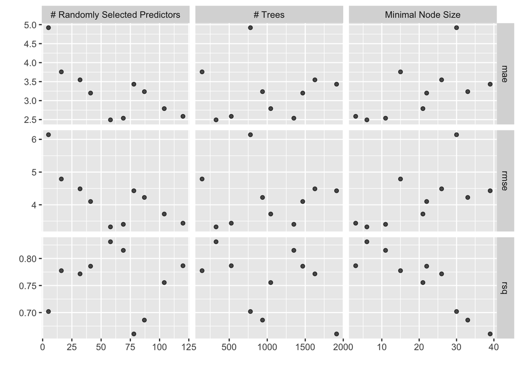

```r
autoplot(rf_results)
```

```r
collect_metrics(rf_results)
```

| mtry | trees | min_n | .metric | .estimator | mean | n | std_err | .config |
| --- | --- | --- | --- | --- | --- | --- | --- | --- |
| 32 | 1627 | 26 | mae | standard | 3.55 | 5 | 0.226 | Preprocessor1_Model01 |
| 32 | 1627 | 26 | rmse | standard | 4.49 | 5 | 0.374 | Preprocessor1_Model01 |
| 32 | 1627 | 26 | rsq | standard | 0.77 | 5 | 0.023 | Preprocessor1_Model01 |
| 41 | 1467 | 22 | mae | standard | 3.20 | 5 | 0.214 | Preprocessor1_Model02 |
| 41 | 1467 | 22 | rmse | standard | 4.10 | 5 | 0.362 | Preprocessor1_Model02 |
| 41 | 1467 | 22 | rsq | standard | 0.79 | 5 | 0.025 | Preprocessor1_Model02 |
| 104 | 1046 | 21 | mae | standard | 2.79 | 5 | 0.176 | Preprocessor1_Model03 |
| 104 | 1046 | 21 | rmse | standard | 3.72 | 5 | 0.333 | Preprocessor1_Model03 |
| 104 | 1046 | 21 | rsq | standard | 0.76 | 5 | 0.028 | Preprocessor1_Model03 |
| 87 | 938 | 33 | mae | standard | 3.24 | 5 | 0.201 | Preprocessor1_Model04 |

[output cut: 20 more lines]

```r
# Final Hyperparameter
param_final <- rf_results %>%
  select_best(metric = "mae")
rf_wf <- rf_wf %>%
  finalize_workflow(param_final)
# last fit
rf_fit <- rf_wf %>%
  last_fit(X_split)
# Test Data Predictions
test_performance <- rf_fit %>% collect_predictions()
# Performance metrics
auto_metrics <- metric_set(rsq, rmse, mae)
x4 = auto_metrics(data = test_performance, truth = life_expectancy, estimate = .pred)
x4['model'] = 'random forest'
```

## Conclusion

```r
bind_rows(x1)
```

| .metric | .estimator | .estimate | model |
| --- | --- | --- | --- |
| rsq | standard | 0.86 | lasso |
| rmse | standard | 3.17 | lasso |
| mae | standard | 2.49 | lasso |

```r
bind_rows(x2)
```

| .metric | .estimator | .estimate | model |
| --- | --- | --- | --- |
| rsq | standard | 0.87 | knn |
| rmse | standard | 2.93 | knn |
| mae | standard | 2.36 | knn |

```r
bind_rows(x3)
```

| .metric | .estimator | .estimate | model |
| --- | --- | --- | --- |
| rsq | standard | 0.71 | decision tree |
| rmse | standard | 4.19 | decision tree |
| mae | standard | 3.08 | decision tree |

```r
bind_rows(x4)
```

| .metric | .estimator | .estimate | model |
| --- | --- | --- | --- |
| rsq | standard | 0.87 | random forest |
| rmse | standard | 3.23 | random forest |
| mae | standard | 2.69 | random forest |